# Assignment 4

2020-06-02

## **Problema 1**

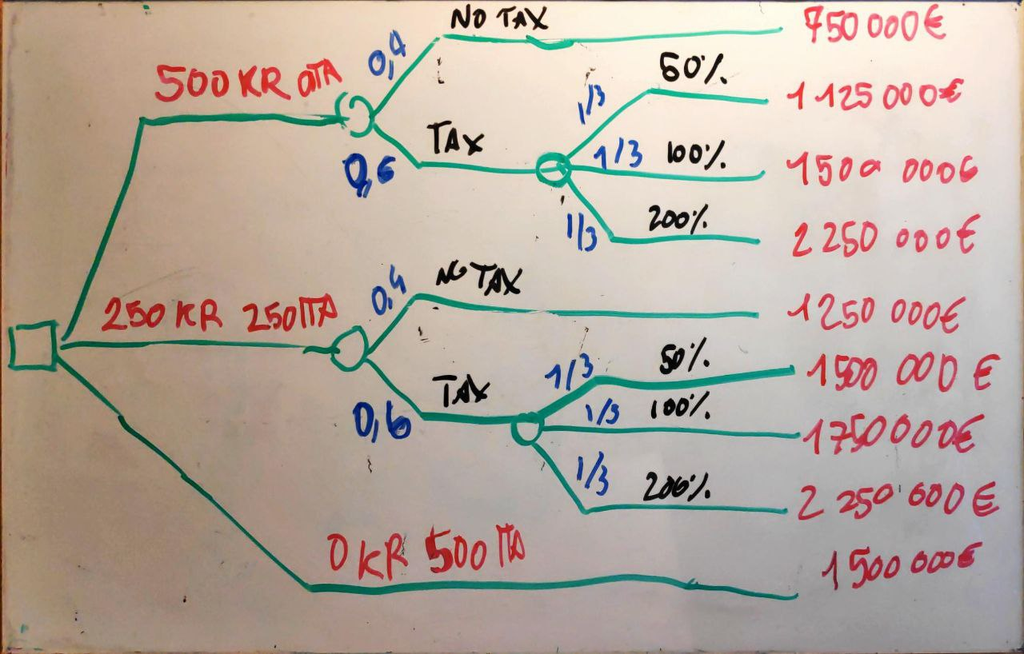

**Decision Tree**

Abbiamo che gli alberi decisionali sono indicati in verde e ne abbiamo 3 che indicano le tre possibili linee di scelta. Rispettivamente sono:

- Comprare $\mathbf{500.000}$ chip direttamente dalla Corea ad un prezzo di $\mathbf{1.50\$}$
- Comprare $\mathbf{250.000}$ chip dalla Corea ad un prezzo di $\mathbf{2.00\$}$ mentre l’altra metà dalla fornitura Italiana al prezzo di $\mathbf{3.00\$}$
- Comprare $\mathbf{500.000}$ chip direttamente dalla fornitura Italiana ad un prezzo di $\mathbf{3.00\$}$

In blu vengono riportate le probabilità. In particolare nel caso di $\mathbf{0.4}$ e $\mathbf{0.6}$ abbiamo che si riferisce alla probabilità di una tassazione o meno del governo italiano nei confronti dell’export, mentre facciamo una assunzione forte di equiprobabilità della ipotetica tassazione al $\mathbf{50\%}$, $\mathbf{100\%}$ e $\mathbf{200\%}$

## **Problema 2**

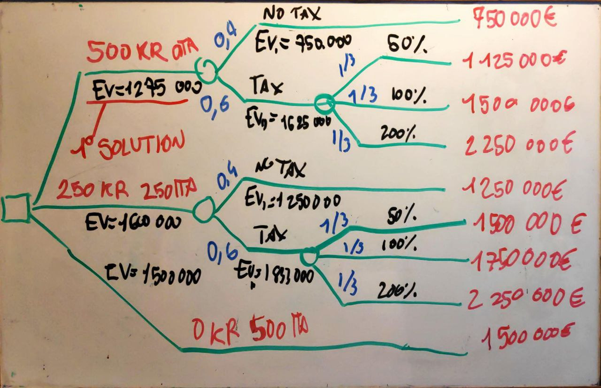

**Decision Tree con EV**

Nella seconda domanda ci viene chiesto di calcolare Expected Value dei rami decisionali, però per comodità concentrandoci sul primo ramo vediamo come la scelta di comprare $\mathbf{500.000}$ chip solo dalla Corea ci mette davanti alla possibilità che venga applicata una tassazione o meno. Nel caso della tassazione dobbiamo perciò calcolarci EV rispetto alle tre possibilità. Perciò avremo una equazione così impostata.
$$\mathbf{EV = (500.000*1.50*1.50*\frac13) +
(500.000*1.50*2.00*\frac13) +
(500.000*1.50*3.00*\frac13) = 1.625.000}$$
Controllo il ramo per cui non ho tassazione ho un $EV = 750.000$ e quindi sommando e moltiplicando le probabilità otteniamo:
$$\mathbf{EV = (750.000 * 0.4) + (1.625.000 * 0.6) = 1.275.000}$$
Calcolando anche per gli altri 2 rami otteniamo $\mathbf{EV = 1.600.000}$ e $\mathbf{EV = 1.500.000}$.
Considerando che stiamo decidendo in base ai costi dobbiamo minimizzare il valore dell’$EV$ pertanto prendiamo la soluzione con $\mathbf{EV = 1.275.000}$.

## **Problema 3**

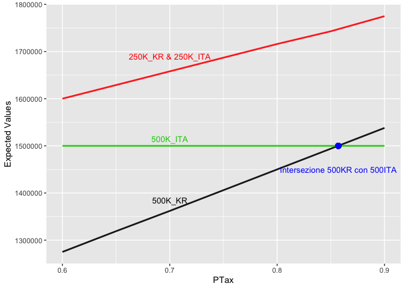

```r
sensitivity <- data.frame("PTax" = c(0.6,0.65,0.7,0.75,0.8,0.85,0.9),
                           "EV1" = c(1275000,1319000,1362000,1406000,1450000,1494000,1538000),
                           "EV2" = c(1600000,1629000,1658000,1687000,1716000,1743000,1775000),
                           "EV3" = c(1500000,1500000,1500000,1500000,1500000,1500000,1500000))

ggplot(sensitivity) +
  geom_line(aes(x=PTax, y=EV1),color= 1, size= 1, alpha= 0.9) +
  geom_line(aes(x=PTax, y=EV2),color= 2, size= 1, alpha= 0.9) +
  geom_line(aes(x=PTax, y=EV3),color= 3, size= 1, alpha= 0.9) +
  labs( y = "Expected Values" ) +
  annotate("text", x = 0.7 ,y = 1385000, label = "500K_KR", size= 3.6, col=1) +
  annotate("text", x = 0.7 ,y = 1690000, label = "250K_KR & 250K_ITA", size=3.6, col= 2) +
  annotate("text", x = 0.7 ,y = 1515000, label = "500K_ITA", size= 3.6, col= 3) +
  geom_point( x = 0.857 ,y = 1500000, colour = "blue", size = 3) +
  annotate("text", x = 0.857 ,y = 1450000, label = "Intersezione 500KR con 500ITA", size=3.6, col="blue")
```

Per la Sensitivity ho deciso di analizzare l’aumento della probabilità che la tassazione si concretizzi. Infatti notiamo che all’aumentare della certezza, si ha una inversione di tendenza nell’intervallo tra $0.8$ e $0.9$ in cui la soluzione totalmente Italiana diventa più conveniente della soluzione totalmente Coreana.

## **Problema 4**

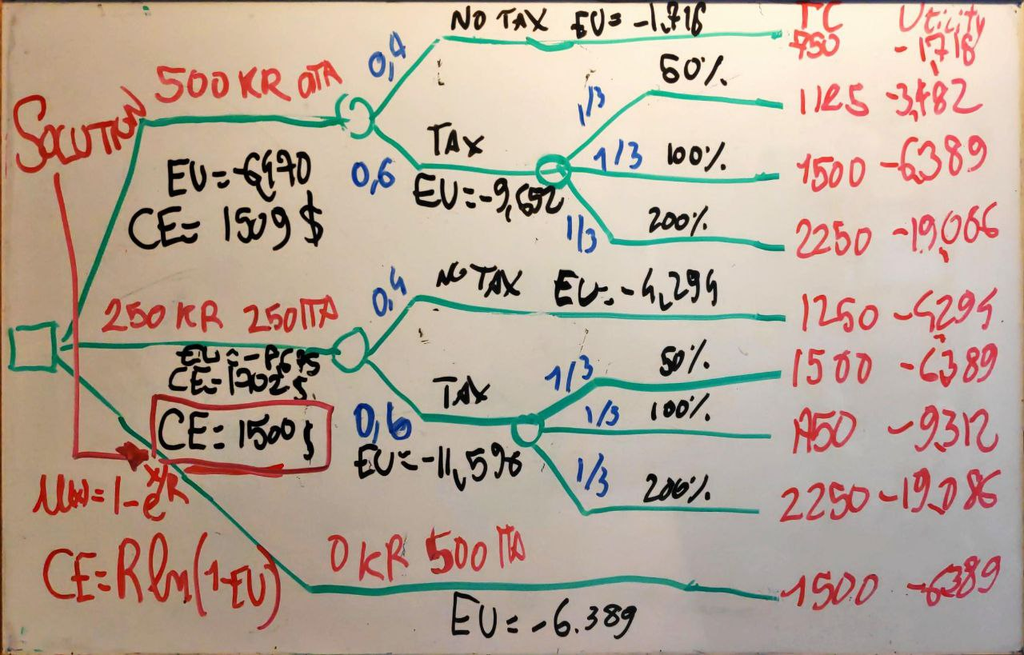

**Decision Tree con Risk Avversion**

Come per il punto 1 considero il ramo decisionale per l’acquisto totale dei chip in Corea e calcolo l’avversione del rischio. Considerando una funzione esponeziale sappiamo dalla teoria che data una utility cosi calcolata:
$$\mathbf{u(x) = 1 - e^\frac{x}{R}}$$
dove $\mathbf{x}$ sono i total cost del ramo, mentre la $\mathbf{R}$ è la risk avversion che ci viene detto essere $\mathbf{750.000\$}$.
Quindi mi calcolo per i 3 rami delle con la Tassazione ed ottengo rispettivamente $-3,482$, $-6,389$ e $-19,086$. Moltiplicandoli per la loro quota di probabilità di $\frac13$ ottengo $EU = -9,652$. Successivamente ho:
$$\mathbf{EU = (-1,718*0,4) + (-9,652*0,6) = -6,470}$$
Quindi mi calcolo **Certainty Equivalent** esponenziale che è uguale a:
$$\mathbf{CE = R*ln(1-EU) = 750.000*ln(1+6,470) = 1.509.000\$}$$
Ripeto le stesso poerzioni per gli altri 2 rami ed ottengo che al contrario del punto 1 la soluzione ottimale diventa quella di comprare direttamente tutti i chip necessari dal produttore Italiano.

## **Problema 5**

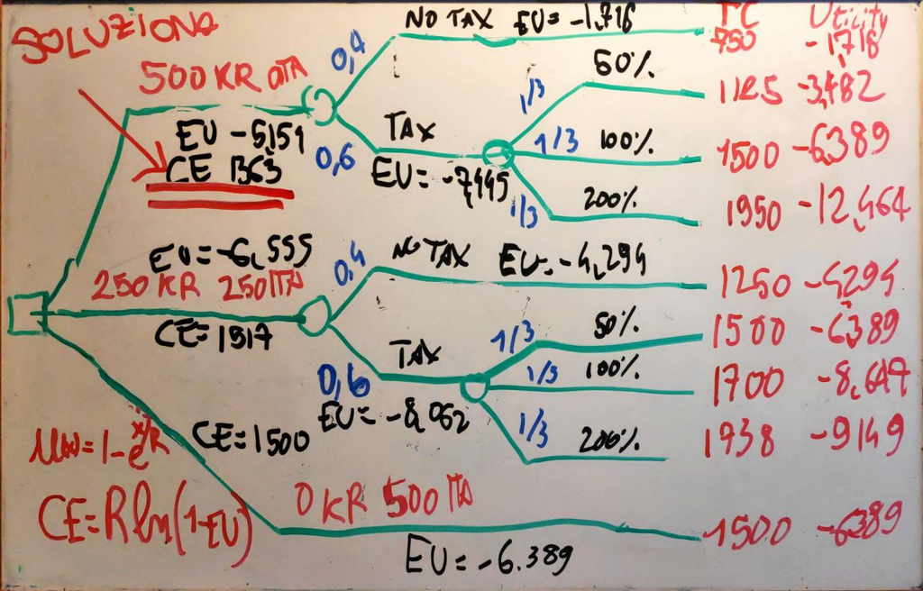

**Decision Tree con Informazione Perfetta**

Una volta che abbiamo una informazione perfetta che la tassa verrà imposta ma con la possibilità di poter cambiare fornitore, dobbiamo ricalcolarci l’utility di tutte le soluzioni trovate al Punto 4 che superano $1.500.000\$$ della soluzione tutta italiana. Allora abbiamo per il ramo 1 la soluzione con il $200\%$ superava mentre per il ramo 2 le soluzioni al $100\%$ e $200\%$. Perciò calcolato per 1 soluzione possiamo iterare. Prendendo le informazioni sappiamo che avremo dei costi Italiani e dei costi di uscita Coreani. Per quanto riguarda la Corea avremo che dovremo pagare il $10\%$ del ordine totale che sulle $500.000$ unità al prezzo di $1,50\$$ è uguale a $75.000\$$. Dal lato italiano sapremo che avremo un aumento del $25\%$ del prezzo degli italiani passando da $3,00\$$ a $3,75\$$ al pezzo. Sommando poi i costi avremo
$$\mathbf{TotalCost = (500.000*3,75) + 75.000}$$
Allora mi calcolo la nuova utility ottenendo $-12,464$. Così cambiando anche le EU avremo che il CE per il ramo 1 sarà uguale a $\mathbf{1363\$}$. Con ragionamenti iterativi ottengo per il ramo 2 $\mathbf{CE = 1517\$}$ e per il ramo 3 $\mathbf{CE = 1500\$}$. Considerando perciò sia la Avversione al Rischio con la Informazione Perfetta rimane la scelta ottimale torna ad essere quella del ramo 1 con il CE minore.

A work by [Alessandro Pontini](https://www.instagram.com/alessandro.pontini/)

*a.pontini1@campus.unimib.it*